# Metabolite Set Enrichment Analysis (MSEA) for metabolomics community

Atsushi Fukushima and Kozo Nishida

RIKEN Center for Sustainable Resource Science  
RIKEN Quantitative Biology Center

afukushima@gmail.com  
knishida@riken.jp

2018-01-22

#### Abstract

Instructions for the MSEAp package.

#### Package

MSEAp 0.0.0.9000

# 1 Introduction

One of the ultimate goals in systems biology is to elucidate the genotype-phenotype relationship in cellular systems [1]. Integrated ‘omics’ approaches have received particular attention. Most omics analyses monitor the levels of target molecules like transcripts and metabolites. In this context, enrichment analysis approaches can be combined with pathway analysis to evaluate whether a particular molecular group is significantly over-represented, for example Gene Set Enrichment Analysis (GSEA) [2-3]. In meteabolomics, one of promising approaches is [Metabolite Set Enrichment Analysis (MSEA)](https://academic.oup.com/nar/article-lookup/doi/10.1093/nar/gkq329) [4]. MSEAp is an R package for performing MSEA using both plant and animal metabolic pathways and metabolite-sets. The package can import pre-defined pathways like KEGG and SMPDB and user-defined metabolite sets in [gmt format](http://software.broadinstitute.org/cancer/software/gsea/wiki/index.php/Data_formats). Their metabolite sets are integrated and used for MSEA calculation. Given a metabolite-set or pathway annotation of metabolites, significance of the over-representation of the metabolites within the pathways is determined by a Fisher’s exact test. The barplot visualization is based on previously established, a web server MSEA in [MetaboAnalyst](http://www.metaboanalyst.ca/) [5]. The package also contains pre-defined and extracted AraCyc that are publicly available and our curated metabolite-sets from MeKO [6], Arabidopsis flavonoid pathways (Tokimatsu, Nishida et al., in preparation), and literatures in plant metabolomics (AtMetExpress, in preparation).

# 2 Installation

```r
## under construction
install.packages("devtools")

source("http://bioconductor.org/biocLite.R")
biocLite(c("KEGGREST", "KEGGgraph"))

library(devtools)
install_github("afukushima/MSEAp")
```

# 3 Getting started

The following is an example of MSEA. `mset_SMPDB_format_KEGG` is a metabolite-set that has the metabolites for each pathway from the [SMPDB](http://smpdb.ca) [7] database with the metabolite ID from the [KEGG](http://www.genome.jp/kegg/) [8] database.

`kusano` is a metabolite list with KEGG metabolite IDs for MESA. This list is corresponding to significantly accumulated metabolites between UV-B (1 day treatment) and control conditions [9]. A typical way to prepare a metabolite list is by testing two hypothesis like t-test and modified t-statistic (e.g. [`limma`](http://bioconductor.org/packages/release/bioc/html/limma.html)).

`msea` performs MSEA and identifies biologically meaningful accumulations in metabolomic data.

`res` is the MSEA result and the `plot` function visualizes the top 20 over-represented pathways.

```r
library(MSEAp)
```

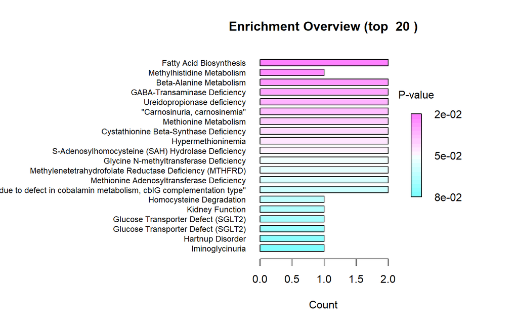

```r
data(mset_SMPDB_format_KEGG)
data(kusano)
res <- msea(mset_SMPDB_format_KEGG, kusano)
plot(res)
```

```r
##
head(kusano)
```

```
## [1] "C00135" "C01595" "C00089" "C00106" "C00490" "C00805"
```

```r
mset_SMPDB_format_KEGG[[1]]
```

```
## [[1]]
## [1] "SMP00055"
##
## [[2]]
## [1] "Alanine Metabolism"
##
## [[3]]
##  [1] "C00002" "C00041" "C00020" "C00013" "C00038" "C00026" "C00025" "C00022"
##  [9] "C00018" "C00288" "C00008" "C00009" "C00036" "C00120" "C19610" "C00048"
## [17] "C00037"
```

# 4 Appetizer

## 4.1 Importing user’s defined metabolite-sets

You can import user’s defined metabolite-sets in [*.gmt format](http://software.broadinstitute.org/cancer/software/gsea/wiki/index.php/Data_formats) using `read.gmt()` function:

```r
file <- system.file("extdata", "sample_SMPDB.gmt", package = "MSEAp")
smp <- read.gmt(file)
```

## 4.2 Importing KGML file

The function `kgml.import()` can extract compound set from [KGML](http://www.kegg.jp/kegg/xml/) file (*.xml) to list.

```r
file <- system.file("extdata/map00260.xml", package="KEGGgraph")## KGML downloaded from KEGG ftp
kgml.import(file)
```

```
## [[1]]
## [1] "map00260"
##
## [[2]]
## [1] "Glycine, serine and threonine metabolism"
##
## [[3]]
##  [1] "C16432" "C06231" "C06442" "C03283" "C00588" "C02855" "C02972" "C02051"
##  [9] "C00258" "C00157" "C00114" "C00576" "C04308" "C00719" "C00197" "C00300"
## [17] "C01241" "C00346" "C01026" "C02992" "C05519" "C00581" "C02412" "C00350"
## [25] "C00641" "C00049" "C03232" "C02291" "C00097" "C00213" "C02553" "C02737"
## [33] "C01005" "C00037" "C00188" "C00109" "C03082" "C00065" "C00048" "C01102"
## [41] "C03508" "C00263" "C00441" "C00740" "C00022" "C00011" "C00430" "C00168"
## [49] "C00014" "C00101" "C01726" "C01888" "C00546" "C05235" "C00143" "C01242"
## [57] "C03194"
```

## 4.3 Importing KEGG pathways

The function `setup.KEGG.gmt()` generates metabolite-sets using the [KEGG REST API](http://www.kegg.jp/kegg/docs/keggapi.html).

```r
res <- setup.KEGG.gmt(listformat = TRUE)
res[[1]]
```

```
## [[1]]
## [1] "map00010"
##
## [[2]]
## [1] "Glycolysis / Gluconeogenesis"
##
## [[3]]
## path:map00010 path:map00010 path:map00010 path:map00010 path:map00010
##      "C00022"      "C00024"      "C00031"      "C00033"      "C00036"
## path:map00010 path:map00010 path:map00010 path:map00010 path:map00010
##      "C00068"      "C00074"      "C00084"      "C00103"      "C00111"
## path:map00010 path:map00010 path:map00010 path:map00010 path:map00010
##      "C00118"      "C00186"      "C00197"      "C00221"      "C00236"
## path:map00010 path:map00010 path:map00010 path:map00010 path:map00010
##      "C00267"      "C00469"      "C00631"      "C00668"      "C01159"
## path:map00010 path:map00010 path:map00010 path:map00010 path:map00010
##      "C01172"      "C01451"      "C05125"      "C05345"      "C05378"
## path:map00010 path:map00010 path:map00010 path:map00010 path:map00010
##      "C06186"      "C06187"      "C06188"      "C15972"      "C15973"
## path:map00010
##      "C16255"
```

## 4.4 Conversion of KEGG’s tar.gz into metabolite-set

The function `setupPathwayClass()` performs convertion of KEGG’s tar.gz files (e.g. hsa.tar.gz) to metabolite-set list.

```r
## filepath <- "./hsa.tar.gz" ## *.tar.gz downloaded from KEGG
## res <- setupPathwayClass(filepath) ## convert to list
```

## 4.5 Metabolite-sets

You can see the currently available datasets using `supported.msets()`:

```r
supported.msets()
```

```
##  [1] "mset_AraCyc_format_HMDB"
##  [2] "mset_AraCyc_format_KEGG"
##  [3] "mset_AtMetExpress_Flavonoids_format_KNApSAcK"
##  [4] "mset_AtMetExpress_Stress_format_KEGG"
##  [5] "mset_EcoCyc_format_HMDB"
##  [6] "mset_EcoCyc_format_KEGG"
##  [7] "mset_FlyCyc_format_KEGG"
##  [8] "mset_HumanCyc_format_KEGG"
##  [9] "mset_MetaCyc_format_HMDB"
## [10] "mset_MetaCyc_format_KEGG"
## [11] "mset_MouseCyc_format_KEGG"
## [12] "mset_PlantCyc_format_HMDB"
## [13] "mset_PlantCyc_format_KEGG"
## [14] "mset_SMPDB_Metabolic_format_HMDB"
## [15] "mset_SMPDB_format_HMDB"
## [16] "mset_SMPDB_format_KEGG"
```

Below is a table of the number of our metabolite-sets.

| Data source | KEGG | HMDB | KNApSAcK |  |
| --- | --- | --- | --- | --- |
| SMPDB | 717 | 717 | NA |  |
| AraCyc | 268 | 350 | NA |  |
| PlantCyc | 606 | 714 | NA |  |
| EcoCyc | 222 | 254 | NA |  |
| MetaCyc | 1861 | 2059 | NA |  |
| HumanCyc | 89 | NA | NA |  |
| MouseCyc | 71 | NA | NA |  |
| FlyCyc | 90 | NA | NA |  |
| AtMetExpress (Stress) | 9 | NA | NA |  |
| AtMetExpress (2nd Metabolism) | NA | NA | 4 |  |

## 4.6 For plant scientists

You can perform MSEA using AraCyc pathways and our curated metabolite sets (flavonoid pathways and some litterature).

```r
data(mset_AraCyc_format_KEGG)
data(mset_AtMetExpress_Stress_format_KEGG)
data(mset_AtMetExpress_Flavonoids_format_KNApSAcK)
mset <- c(
  mset_AraCyc_format_KEGG,
  mset_AtMetExpress_Stress_format_KEGG,
  mset_AtMetExpress_Flavonoids_format_KNApSAcK
  )
length(mset) ## 281 metabolite-sets
```

```
## [1] 281
```

Here `fukushima17_INC` is a metabolite list and contains 37 significant increased metabolites including primary- and secondary metabolites, mainly flavonols and anthocyanins between mild oxidative stress and control conditions [10]. We can use both KEGG and KNApSAcK IDs for MSEA.

```r
data(fukushima17_INC)
head(fukushima17_INC)
```

```
##                  Metabolite source      HMDB kegg_knap
## 1             Dihydrouracil     GC HMDB00076    C00429
## 2                   glycine     GC HMDB00123    C00037
## 3 threonic acid-1,4-lactone     GC HMDB00940      <NA>
## 4              beta-alanine     GC HMDB00056    C00099
## 5           l-threonic acid     GC HMDB00943    C01620
## 6                  d-xylose     GC HMDB00098    C00181
```

```r
res <- msea(mset, fukushima17_INC$kegg_knap)
head(res)
```

```
##                 pathway.ID
## 272          LEAVES_HL_INC
## 269 LEAVES_Dehydration_INC
## 271        LEAVES_Cold_INC
## 274       LEAVES_S-lim_INC
## 270        LEAVES_Heat_INC
## 273          LEAVES_UV_INC
##                                                                                                                                                  Metaboliteset.name
## 272 Increased metabolites in Arabidopsis leaves under high-light (HL) stress condition. References: Wulff-Zottele et al. Plant Cell Environ (2010) [PMID: 20573050]
## 269                        Increased metabolites in Arabidopsis leaves under dehydration stress condition. References: Urano et al. Plant J (2009) [PMID: 19036030]
## 271                        Increased metabolites in Arabidopsis leaves under cold stress condition. References: Kaplan et al. Plant Physiol (2004) [PMID: 15557093]
## 274     Increased metabolites in Arabidopsis leaves under sulphur limitation condition. References: Wulff-Zottele et al. Plant Cell Environ (2010) [PMID: 20573050]
## 270                        Increased metabolites in Arabidopsis leaves under heat stress condition. References: Kaplan et al. Plant Physiol (2004) [PMID: 15557093]
## 273                              Increased metabolites in Arabidopsis leaves under UV-B stress condition. References: Kusano et al. Plant J (2011) [PMID: 21466600]
##     Total Expected Hit   p.value      Holm.p                 FDR
```

[output cut: 20 more lines]

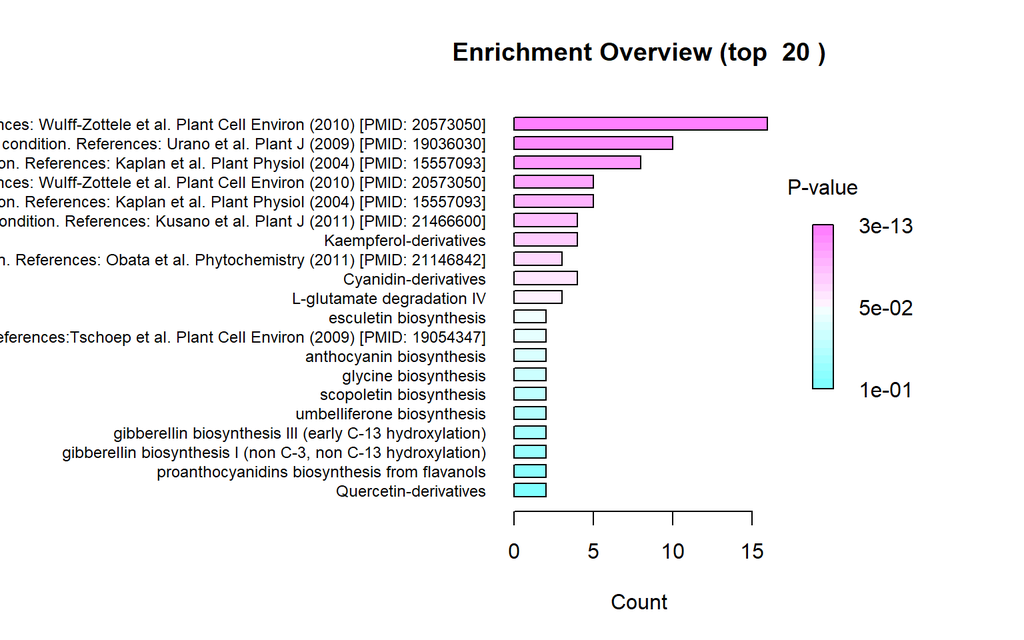

```r
plot(res)
```

# 5 Visualization of MSEA results

To help interpreting MSEA result, we also implemented `barplot`, `dotplot` and `netplot` for visualization.

`barplot` plots pvalue as color and the number of metabolite queries contained in the metabolite group as the height of bar.

`dotplot` plots dots on the expected value of msea in each group, with pvalue as color (like barplot) and the number of metabolite queries contained in the metabolite group as the size of dot.

`netplot` recieves the MSEA result, the metabolite set and `shared.metabolite` argument and plots the pvalue in the MSEA result as the node color on the network of the metabolite group. The size of node indicates the number of metabolite queries contained in the metabolite group. The `shared.metabolite` argument decides how to connect the metabolite group with the edge. In the example below, if there are more than 20 metabolites common among groups, we connect these groups with edge.

By default, `netplot` performs visualization using the visNetwork package, but you can add `sendto` argument and make the output destination Cytoscape. In the default plot, it is possible to use interactive functions such as mouseover popup of MSEA information.

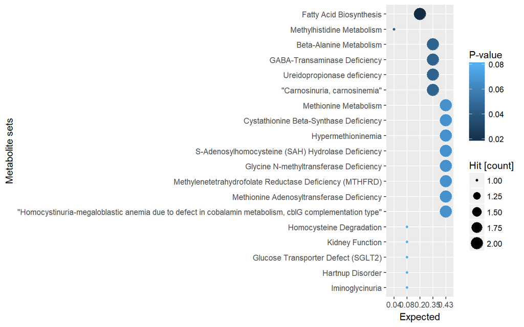

```r
res <- msea(mset_SMPDB_format_KEGG, kusano)
dotplot(res)  ## You may have to zoom this plot in RStudio and other R working environments
```

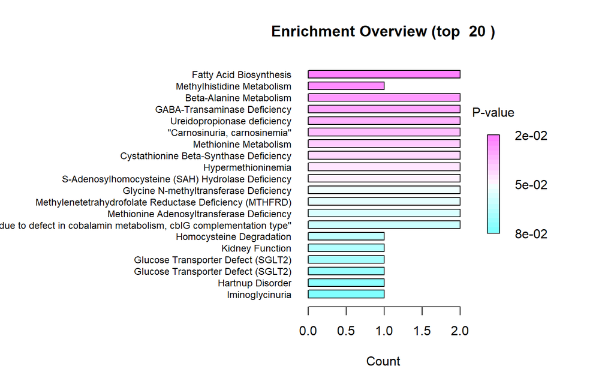

```r
barplot(res)  ## You can see the same plot by plot()
```

```r
netplot(res, mset_SMPDB_format_KEGG, shared.metabolite = 20)
```

[interactive chart not shown]

# 6 Acknowledgments

We thank Dr. Toshiaki Tokimatsu in NIG for manual curation of the flavonoid biosynthetic pathway in *Arabidopsis thaliana*.

# 7 References

1. Fukushima A, Kanaya S, Nishida K: Integrated network analysis and effective tools in plant systems biology. [Front Plant Sci. 2014 Nov 4;5:598. doi: 10.3389/fpls.2014.00598](https://dx.doi.org/10.3389/fpls.2014.00598).
2. Mootha VK, Lindgren CM, Eriksson KF, Subramanian A, Sihag S, Lehar J, Puigserver P, Carlsson E, Ridderstråle M, Laurila E, Houstis N, Daly MJ, Patterson N, Mesirov JP, Golub TR, Tamayo P, Spiegelman B, Lander ES, Hirschhorn JN, Altshuler D, Groop LC: PGC-1alpha-responsive genes involved in oxidative phosphorylation are coordinately downregulated in human diabetes. [Nat Genet. 2003 Jul;34(3):267-273](http://www.nature.com/ng/journal/v34/n3/abs/ng1180.html).
3. Subramanian A, Tamayo P, Mootha VK, Mukherjee S, Ebert BL, Gillette MA, Paulovich A, Pomeroy SL, Golub TR, Lander ES, Mesirov JP: Gene set enrichment analysis: a knowledge-based approach for interpreting genome-wide expression profiles. [Proc Natl Acad Sci U S A. 2005 Oct 25;102(43):15545-15550](http://www.pnas.org/content/102/43/15545.abstract).
4. Xia J and Wishart DS: MSEA: a web-based tool to identify biologically meaningful patterns in quantitative metabolomic data. [Nucleic Acids Res. 2010 Jul;38(Web Server issue):W71-77. doi: 10.1093/nar/gkq329](https://academic.oup.com/nar/article-lookup/doi/10.1093/nar/gkq329).
5. Xia J, Sinelnikov IV, Han B, Wishart DS: MetaboAnalyst 3.0–making metabolomics more meaningful. [Nucleic Acids Res. 2015 Jul 1;43(W1):W251-257. doi: 10.1093/nar/gkv380](https://academic.oup.com/nar/article-lookup/doi/10.1093/nar/gkv380).
6. Fukushima A, Kusano M, Mejia RF, Iwasa M, Kobayashi M, Hayashi N, Watanabe-Takahashi A, Narisawa T, Tohge T, Hur M, Wurtele ES, Nikolau BJ, Saito K: Metabolomic Characterization of Knockout Mutants in Arabidopsis: Development of a Metabolite Profiling Database for Knockout Mutants in Arabidopsis. [Plant Physiol. 2014 Jul;165(3):948-961](http://www.plantphysiol.org/content/165/3/948.long).
7. Jewison T, Su Y, Disfany FM, Liang Y, Knox C, Maciejewski A, Poelzer J, Huynh J, Zhou Y, Arndt D, Djoumbou Y: SMPDB 2.0: big improvements to the Small Molecule Pathway Database. [Nucleic acids research. 2013 Nov 6;42(D1):D478-84](https://academic.oup.com/nar/article/42/D1/D478/1047198).
8. Kanehisa M, Furumichi M, Tanabe M, Sato Y, Morishima K: KEGG: new perspectives on genomes, pathways, diseases and drugs. [Nucleic acids research. 2017 Jan 4;45(D1):D353-61](https://academic.oup.com/nar/article/45/D1/D353/2605697).
9. Kusano M, Tohge T, Fukushima A, Kobayashi M, Hayashi N, Otsuki H, Kondou Y, Goto H, Kawashima M, Matsuda F, Niida R, Matsui M, Saito K, Fernie AR: Metabolomics reveals comprehensive reprogramming involving two independent metabolic responses of Arabidopsis to UV-B light. [Plant J. 2011 67(2):354-69](http://onlinelibrary.wiley.com/doi/10.1111/j.1365-313X.2011.04599.x/abstract).
10. Fukushima A, Iwasa M, Nakabayashi R, Kobayashi M, Nishizawa T, Okazaki Y, Saito K, Kusano M: Effects of Combined Low Glutathione with Mild Oxidative and Low Phosphorus Stress on the Metabolism of Arabidopsis thaliana. [Front Plant Sci. 2017 Aug 28;8:1464](https://www.frontiersin.org/articles/10.3389/fpls.2017.01464/full).